# Cyclistic Casual Rider Conversion Case Study

# ANALYZE

### Classify Days as Weekdays or Weekends

Classify days as weekdays or weekends.

```r
tripdata_combined_clean <- tripdata_combined_clean %>% mutate(day_type = ifelse(weekday %in% c("Sat", "Sun"), "weekend", "weekday"))
```

### Calculate Average Ride Length

Calculate the average ride length for members and casual riders.

```r
# Calculate average ride length for members and casual riders
avg_ride_length <- tripdata_combined_clean %>%
  group_by(member_casual) %>%
  summarise(avg_ride_length = mean(ride_length, na.rm = TRUE))

# Calculate average ride length for weekdays and weekends for members and casual riders
avg_ride_length_day_type <- tripdata_combined_clean %>%
  group_by(member_casual, day_type) %>%
  summarise(avg_ride_length = mean(ride_length, na.rm = TRUE), .groups = 'drop')

# Separate variables for members and casual riders
avg_ride_length_members <- avg_ride_length %>%
  filter(member_casual == "member") %>%
  .$avg_ride_length

avg_ride_length_casual <- avg_ride_length %>%
  filter(member_casual == "casual") %>%
  .$avg_ride_length

# Separate variables for average ride length on weekdays and weekends for members
avg_ride_length_members_weekday <- avg_ride_length_day_type %>%
  filter(member_casual == "member" & day_type == "weekday") %>%
  .$avg_ride_length

avg_ride_length_members_weekend <- avg_ride_length_day_type %>%
  filter(member_casual == "member" & day_type == "weekend") %>%
  .$avg_ride_length

# Separate variables for average ride length on weekdays and weekends for casual riders
avg_ride_length_casual_weekday <- avg_ride_length_day_type %>%
  filter(member_casual == "casual" & day_type == "weekday") %>%
  .$avg_ride_length

avg_ride_length_casual_weekend <- avg_ride_length_day_type %>%
  filter(member_casual == "casual" & day_type == "weekend") %>%
  .$avg_ride_length

# Display results
print(avg_ride_length_members)
```

```
## Time difference of 767.6967 secs
```

```r
print(avg_ride_length_casual)
```

```
## Time difference of 1508.474 secs
```

```r
print(avg_ride_length_members_weekday)
```

```
## Time difference of 740.779 secs
```

```r
print(avg_ride_length_members_weekend)
```

```
## Time difference of 853.1703 secs
```

```r
print(avg_ride_length_casual_weekday)
```

```
## Time difference of 1377.52 secs
```

```r
print(avg_ride_length_casual_weekend)
```

```
## Time difference of 1725.887 secs
```

### Determine the Most Common Day of Usage

Determine the most common day of usage for members and casual riders.

```r
# Group by member status and weekday, then count the occurrences
weekday_counts <- tripdata_combined_clean %>%
  group_by(member_casual, weekday) %>%
  summarise(count = n(), .groups = 'drop')

# Find Most Common Day for Members
most_common_day_member <- weekday_counts %>%
  filter(member_casual == "member") %>%
  slice_max(count) %>%
  select(weekday, count)

# Find Most Common Day for Casuals
most_common_day_casual <- weekday_counts %>%
  filter(member_casual == "casual") %>%
  slice_max(count) %>%
  select(weekday, count)

# Display Results
print(most_common_day_casual)
```

```
## # A tibble: 1 × 2
##   weekday  count
##   <ord>    <int>
## 1 Sat     447852
```

```r
print(most_common_day_member)
```

```
## # A tibble: 1 × 2
##   weekday  count
##   <ord>    <int>
## 1 Wed     630179
```

```r
print(weekday_counts)
```

```
## # A tibble: 16 × 3
##    member_casual weekday  count
##    <chr>         <ord>    <int>
##  1 casual        Sun     367969
##  2 casual        Mon     251864
##  3 casual        Tue     232189
##  4 casual        Wed     275740
##  5 casual        Thu     277437
##  6 casual        Fri     317216
##  7 casual        Sat     447852
##  8 casual        <NA>         1
##  9 member        Sun     416552
## 10 member        Mon     529941
## 11 member        Tue     569276
## 12 member        Wed     630179
## 13 member        Thu     603085
## 14 member        Fri     529610
## 15 member        Sat     484794
## 16 member        <NA>         7
```

```r
# Classify 'weekday' as weekend or weekday
tripdata_combined_clean <- tripdata_combined_clean %>%
  mutate(day_type = ifelse(weekday %in% c("Sat", "Sun"), "weekend", "weekday"))

# Group by 'member_casual' and 'day_type', then count
day_type_counts <- tripdata_combined_clean %>%
  group_by(member_casual, day_type) %>%
  summarise(count = n(), .groups = 'drop')

# Calculate average number of trips weekdays vs weekends
avg_trips <- day_type_counts %>%
  group_by(member_casual) %>%
  summarise(
    avg_weekday_trips = mean(count[day_type == "weekday"]),
    avg_weekend_trips = mean(count[day_type == "weekend"])
  )

# Display results
print(avg_trips)
```

```
## # A tibble: 2 × 3
##   member_casual avg_weekday_trips avg_weekend_trips
##   <chr>                     <dbl>             <dbl>
## 1 casual                  1354447            815821
## 2 member                  2862098            901346
```

### Calculate Average Trip Length for Both Casual and Member Users

Calculate average trip length for both casual and member users.

```r
# Convert 'ride_length' from difftime to numeric minutes
tripdata_combined_clean <- tripdata_combined_clean %>%
  mutate(ride_length_minutes = as.numeric(ride_length, units = "mins"))

# Calculate average ride length for each user type
avg_ride_length_by_day <- tripdata_combined_clean %>%
  group_by(member_casual, weekday) %>%
  summarise(avg_ride_length = mean(ride_length_minutes, na.rm = TRUE), .groups = 'drop')

# Split results into separate dataframes
avg_ride_length_casual <- avg_ride_length_by_day %>%
  filter(member_casual == "casual")
avg_ride_length_members <- avg_ride_length_by_day %>%
  filter(member_casual == "member")

# Display results
print(avg_ride_length_casual)
```

```
## # A tibble: 8 × 3
##   member_casual weekday avg_ride_length
##   <chr>         <ord>             <dbl>
## 1 casual        Sun                29.5
## 2 casual        Mon                24.2
## 3 casual        Tue                21.6
## 4 casual        Wed                22.2
## 5 casual        Thu                21.9
## 6 casual        Fri                24.5
## 7 casual        Sat                28.2
## 8 casual        <NA>              NaN
```

```r
print(avg_ride_length_members)
```

```
## # A tibble: 8 × 3
##   member_casual weekday avg_ride_length
##   <chr>         <ord>             <dbl>
## 1 member        Sun                14.3
## 2 member        Mon                12.3
## 3 member        Tue                12.3
## 4 member        Wed                12.4
## 5 member        Thu                12.3
## 6 member        Fri                12.4
## 7 member        Sat                14.2
## 8 member        <NA>              NaN
```

# SHARE

## Supporting Visualizations and Key Findings

### Number of Trips by Day of the Week

#### Define the Order for Weekdays

Define the correct order for the weekdays.

```r
# Define the correct order for weekdays
weekday_order <- c("Mon", "Tue", "Wed", "Thu", "Fri", "Sat", "Sun")
```

#### Convert ‘weekday’ to a Factor

Convert the ‘weekday’ column to a factor with the specified order and calculate the count in millions.

```r
weekday_counts <- weekday_counts %>%
  mutate(weekday = factor(weekday, levels = weekday_order),
         count_in_millions = count / 1000000)
```

#### Add Units to Y-Axis Labels

Create a function to add units to the Y-axis labels.

```r
add_mil <- function(x){
  paste0(scales::comma_format()(x), "Mil")
}
```

#### Bar Plot

Create a bar plot to visualize the number of trips by day of the week.

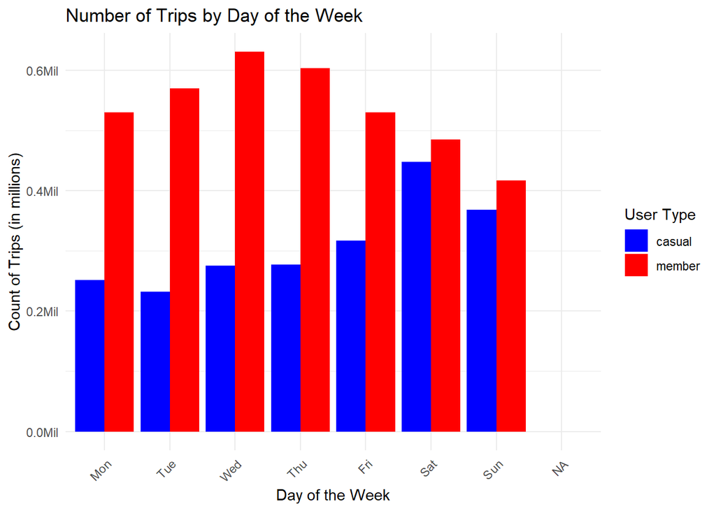

```r
library(ggplot2)

ggplot(weekday_counts, aes(
  x = weekday, y = count_in_millions, fill = member_casual)) +
  geom_bar(stat = "identity", position = "dodge") +
  scale_fill_manual(values = c("casual" = "blue", "member" = "red")) +
  labs(
    title = "Number of Trips by Day of the Week",
    x = "Day of the Week",
    y = "Count of Trips (in millions)",
    fill = "User Type"
  ) +
  scale_y_continuous(labels = add_mil) +
  theme_minimal() +
  theme(axis.text.x = element_text(angle = 45, hjust = 1))
```

### Visualization of Average Trip lengths by user type per day

#### Combine Data for Casual and Member Users

Combine `avg_ride_length_casual` and `avg_ride_length_members` into a single dataframe.

```r
avg_ride_length_combined <- bind_rows(avg_ride_length_casual, avg_ride_length_members)
```

#### Define the Order for Weekdays

Define the correct order for the weekdays and convert the ‘weekday’ column to a factor with the specified order.

```r
weekday_order <- c("Mon", "Tue", "Wed", "Thu", "Fri", "Sat", "Sun")

avg_ride_length_combined <- avg_ride_length_combined %>%
  mutate(weekday = factor(weekday, levels = weekday_order))
```

#### Add Units to Y-Axis Labels

Create a custom function to add ‘Min’ to the y-axis labels.

```r
add_min <- function(x) {
  paste0(comma(x), " Min")
}
```

#### Bar Plot

Create a bar plot to visualize the average ride lengths by day of the week for casual and member users.

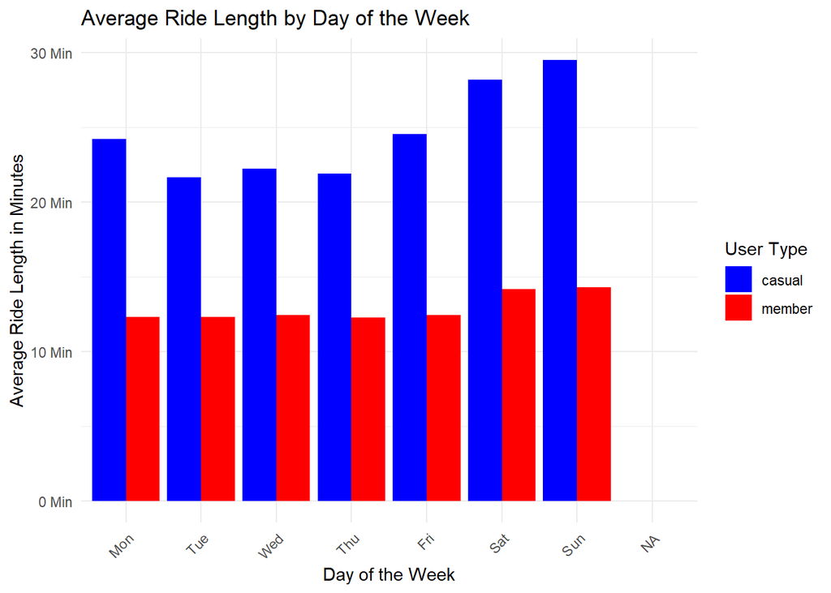

```r
library(ggplot2)

ggplot(avg_ride_length_combined, aes(
  x = weekday, y = avg_ride_length, fill = member_casual)) +
  geom_bar(stat = "identity", position = "dodge") +
  scale_fill_manual(values = c("casual" = "blue", "member" = "red")) +
  labs(
    title = "Average Ride Length by Day of the Week",
    x = "Day of the Week",
    y = "Average Ride Length in Minutes",
    fill = "User Type"
  ) +
  scale_y_continuous(labels = add_min) +
  theme_minimal() +
  theme(axis.text.x = element_text(angle = 45, hjust = 1))
```

## Key Findings As Related to Business Task

- How do annual members and casual riders use Cyclistic bikes differently?
  - Members use bikes primarily for commuting while casuals seem to primarily use them for recreation.
- Why would casual riders buy Cyclistic annual memberships?
  - If the value of being members were demonstrated over their current means of commuting.
- How can Cyclistic use digital media to influence casual riders to become members?
  - Digital marketing that focuses on how much money can be saved by riding to work-week.
  - Targeted advertising on areas with a high density of commuters.
  - Build partnerships with local employers to offer services as part of employee befits packages.

# ACT

## Top Three Recommendations Based on Analysis

1. **Promotional Campaigns**
- *“Commute & Save” Offers* - Highlight the cost savings of an annual membership compared to occasional rentals, especially for commuters.
- *Limited-Time Discounts* - Offer discounted rates or free trials for the first month to encourage sign-ups.
2. **Targeted Advertising:**
- *Geographical Targeting* - Focus on areas with a high density of potential commuters, like residential neighborhoods near business districts.
- *Segmented Marketing* - Tailor messages to different demographic groups, emphasizing convenience for young professionals and cost savings for families.
3. **Workplace Partnerships:**
- *Corporate Memberships* - Partner with businesses to offer corporate memberships as part of employee benefits packages.
- *Incentive Programs* - Encourage employers to provide incentives for employees who bike to work, such as wellness programs or reimbursements.